# Isentia (Junior Data Scientist Exam) - Juice Dataset Analyses

John Kenneth Fajardo

8/21/2021

## Overview

This documentation presents how text analyses and natural language processing have been used to gather insights for what we would call “Juice Dataset”. This is a technical assessment for the Junior Data Scientist role at Isentia.

## Business Problem

Observing the raw data, we can infer that the content comes from personal posts that contain the word “juice”. The word is used differently as it relates to beverages, creativity, and even batteries. In order to gather insights, we did **topic modeling**, and looked for the **top n-grams** to learn what people think about when they mention “juice” in their posts.

## Exploratory Analysis

1. Social Networking Sites - Facebook Pages (1,845 obs.)
2. Microblogs - Twitter (2,528 obs.)
3. Forums (3,699 obs.)

All posts were created in the Singapore region. For visualizations of the data, a dashboard is made available [here](https://public.tableau.com/app/profile/john.kenneth.fajardo/viz/Isentia/Dashboard1), via Tableau Public. A screenshot of the dashboard can be seen below.

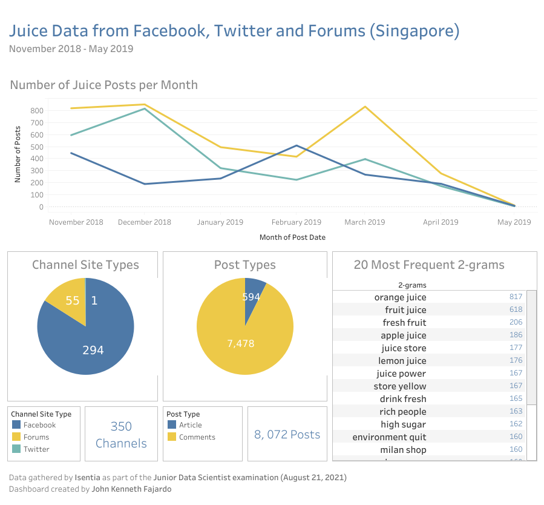

Fig. 1: Dashboard for the Juice Exploratory Analysis

## Topic Modeling

The statistical model used for assigning topics is *Latent Dirichlet Allocation* (LDA). With the help of the R library, *Quanteda*, we are able to categorize the following group of keywords to help analysts deduce and choose related topics:

### Table 1: 10 LDA-generated Topics with Their Respective Associated Terms

| topic1 | topic2 | topic3 | topic4 | topic5 | topic6 | topic7 | topic8 | topic9 | topic10 |
| --- | --- | --- | --- | --- | --- | --- | --- | --- | --- |
| juice | juice | hours | juice | china | water | juice | juice | sugar | time |
| juices | orange | clean | wrote | road | singapore | china | chicken | food | good |
| food | drink | machine | sent | power | juice | government | sauce | drinks | people |
| stall | fruit | inside | gagt | shelf | gallons | wife | rice | health | help |
| daily | fresh | juice | drink | retrograde | juiced | trump | beef | high | life |
| drinks | people | think | coconut | even | daily | property | water | diet | work |
| singapore | store | want | milk | asia | cane | children | make | people | make |
| fruit | week | time | apple | karakoram | million | shutdown | lemon | weight | need |
| school | shop | better | carrot | juices | mango | white | sugar | fruit | think |
| drink | house | every | lemon | travel | malaysia | president | pineapple | foods | aluminium |

Since the key terms are already grouped for us, we can easily assign topic names for each group. For example, `topic7` can be renamed as “Politics” and `topic8` can be renamed as “Ingredients in Recipes”.

### Table 2: Number of Documents Assigned to the Topics

| Var1 | Freq |
| --- | --- |
| topic1 | 922 |
| topic2 | 1423 |
| topic3 | 870 |
| topic4 | 1604 |
| topic5 | 377 |
| topic6 | 611 |
| topic7 | 472 |
| topic8 | 611 |
| topic9 | 507 |
| topic10 | 621 |

The table includes the number of documents classified in the respective topics. For example, 472 documents in the dataset talk about politics.

## Word Frequency

In addition to topic modeling, we can also form insights from just observing the most frequent words and n-grams.

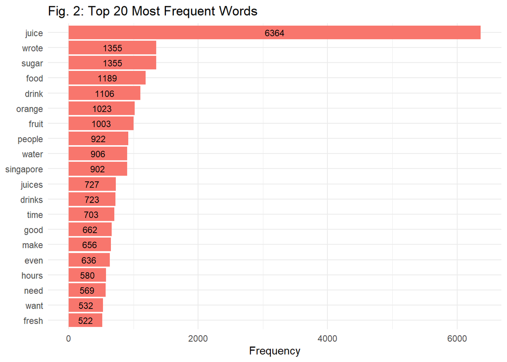

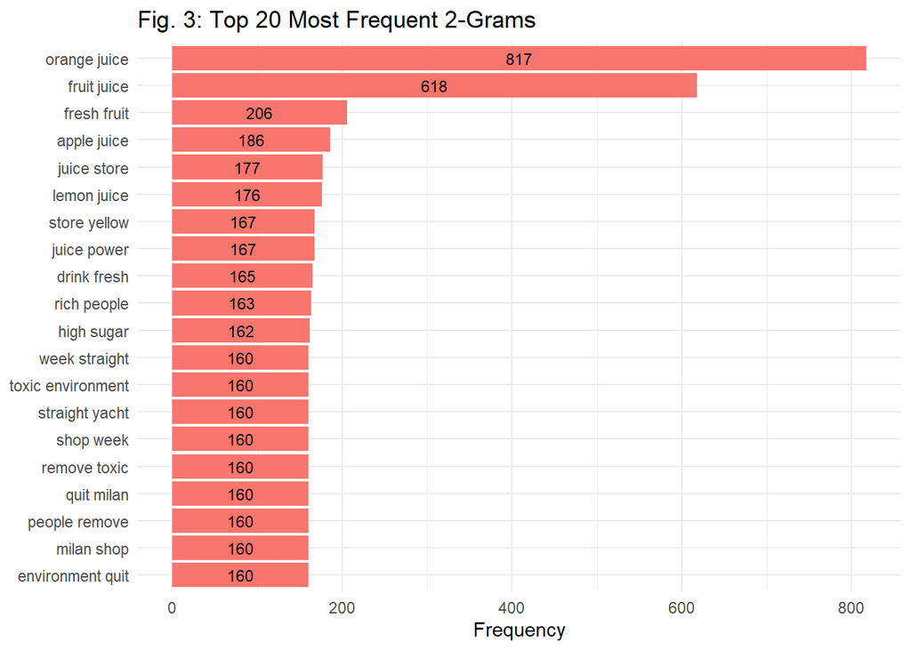

We can see different types of juice mentioned, the phrase “rich people” may imply that juice is common among the affluent people, and the phrase “high sugar” may lead to the inclusion of health in the discourse on juices especially store-bought ones, and so on.

## Sentiment Analysis

To observe user activity, particularly if the polarities are either positive or negative based from the word usage in their posts, a polarity-vs-time graph was generated. This would help the analysts pinpoint the dates where the word “juice” became a trend for both good and bad reasons.

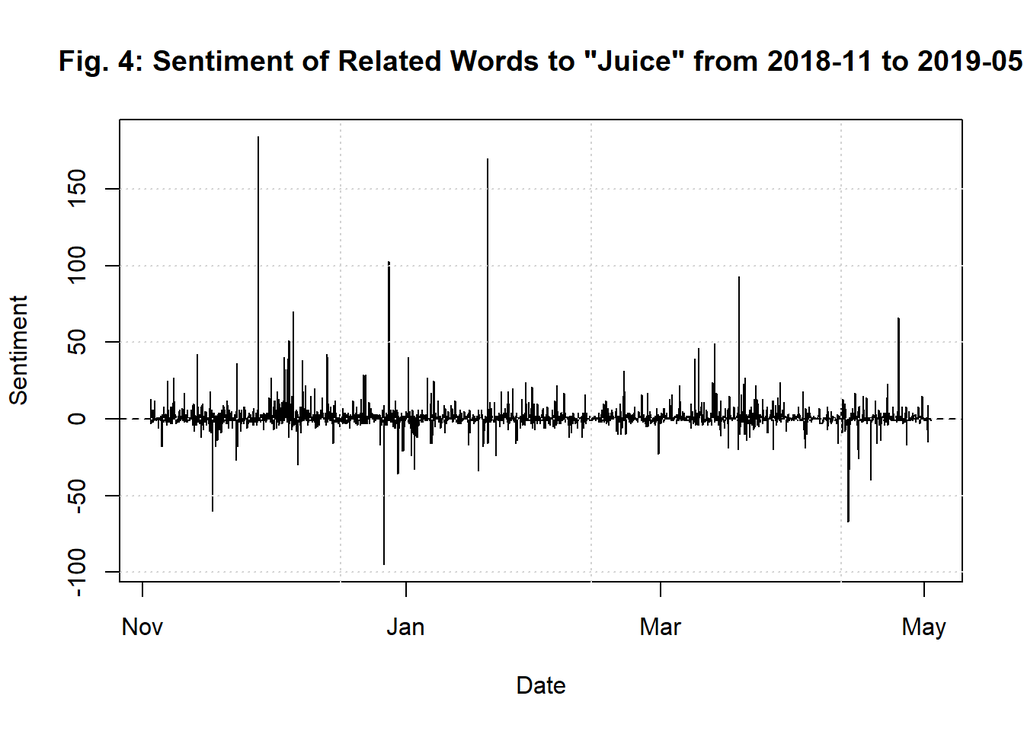

## Conclusion

Before cleaning the sporadic data, looking at the dataset led to multiple, unorganized observations. With the help of topic modeling and document-frequency matrices, we were able to limit and identify topic classifications. A sentiment analysis was also included to illustrate data points where there are significant increases in polarity over time. With these distilled information from a vast load of information, we help our analysts craft clear-cut conclusions that benefit our clients and the technological world.